# PROJEKT 1

Piotr Filipiak, Kacper Brongiel, Jakub Morawski, Paweł Modzelewski

2026-02-05

# 1. Analiza danych transakcyjnych

## 1.1. Przygotowanie danych

```r
library(tidyverse)
library(gridExtra)
#library(lubridate) bo tidyverse
library(e1071)
library(tseries)
#library(ggplot2) bo tidyverse
library(forecast)
library(moments)
library(rugarch)
library(patchwork)
```

```r
dataH <- read.csv("spolkaH.csv", dec=".", sep=";")
dataL <- read.csv("spolkaL.csv", dec=".", sep=";")

dataH$date_obj <- as.Date(as.character(dataH$daty), format = "%Y%m%d")
dataL$date_obj <- as.Date(as.character(dataL$daty), format = "%Y%m%d")

#spróbujemy tidyverse:

dataH <- dataH |>
  mutate(
    godz6 = sprintf("%06d", godz),
    #dwukropki
    czas = paste0(
      substr(godz6, 1, 2), ":",
      substr(godz6, 3, 4), ":",
      substr(godz6, 5, 6)
    ),
    znacznik = ymd_hms(paste(daty, czas))
  ) |>
  select(znacznik, cena, vol)

dataL <- dataL |>
  mutate(
    godz6 = sprintf("%06d", godz),
    #dwukropki
    czas = paste0(
      substr(godz6, 1, 2), ":",
      substr(godz6, 3, 4), ":",
      substr(godz6, 5, 6)
    ),
    znacznik = ymd_hms(paste(daty, czas))
  ) |>
  select(znacznik, cena, vol)

dataH <- dataH |>
  filter(
    #daty
    as_date(znacznik) >= as.Date("2019-01-01") &
    as_date(znacznik) <= as.Date("2019-06-30"),

    #godziny
    znacznik >= floor_date(znacznik, "day") + hours(9) &
    znacznik <= floor_date(znacznik, "day") + hours(17) + minutes(5)
  )

dataL <- dataL |>
  filter(
    #daty
    as_date(znacznik) >= as.Date("2019-01-01") &
    as_date(znacznik) <= as.Date("2019-06-30"),

    #godziny
    znacznik >= floor_date(znacznik, "day") + hours(9) &
    znacznik <= floor_date(znacznik, "day") + hours(17) + minutes(5)
  )
```

## 1.2. Statystyki opisowe

### 1.2.1. Kod

```r
stat <- function(x){
  n <- length(x)
  summ <- summary(x)
  sd <- sd(x, na.rm=T)
  mean_val <- mean(x, na.rm=T)
  mad_val <- mad(x, na.rm=T)
  cv_val <- if (mean_val != 0) sd / mean_val else NA
  skew_val <- if (n >= 3) moments::skewness(x) else NA
  kurt_val <- if (n >= 4) moments::kurtosis(x) else NA
  p90 <- quantile(x, 0.90)
  p95 <- quantile(x, 0.95)

  c(
    summ,
    sd = sd,
    MAD = mad_val,
    CV = cv_val,
    Skweness = skew_val,
    Kurtosis = kurt_val,
    P90 = p90,
    P95 = p95
  )
}
```

```r
old_scipen <- getOption("scipen")
options(scipen = 9999999)
```

```r
#cena pojedynczej transakcji
stat(dataH$cena) #H
```

```
##       Min.    1st Qu.     Median       Mean    3rd Qu.       Max.         sd
## 6.59500000 6.97000000 7.69000000 7.69254378 8.35000000 9.13000000 0.74811176
##        MAD         CV   Skweness   Kurtosis    P90.90%    P95.95%
## 1.05264600 0.09725154 0.24261506 1.69282227 8.77000000 8.88000000
```

```r
stat(dataL$cena) #L
```

```
##       Min.    1st Qu.     Median       Mean    3rd Qu.       Max.         sd
## 2.68900000 2.88300000 3.00200000 3.09276504 3.36000000 3.66000000 0.28256532
##        MAD         CV   Skweness   Kurtosis    P90.90%    P95.95%
## 0.33210240 0.09136333 0.45850580 1.86432913 3.54000000 3.59000000
```

```r
#wolumen pojedynczej transakcji
stat(dataH$vol) #H
```

```
##           Min.        1st Qu.         Median           Mean        3rd Qu.
##       1.000000     286.000000     768.000000    1735.221456    1871.000000
##           Max.             sd            MAD             CV       Skweness
## 1027245.000000    7225.886406     916.246800       4.164245      56.647776
##       Kurtosis        P90.90%        P95.95%
##    5474.109739    3301.300000    5000.000000
```

```r
stat(dataL$vol) #L
```

```
##           Min.        1st Qu.         Median           Mean        3rd Qu.
##       1.000000     513.000000    1317.000000    2898.536116    3115.000000
##           Max.             sd            MAD             CV       Skweness
## 2639642.000000   11655.451459    1488.530400       4.021151      95.844451
##       Kurtosis        P90.90%        P95.95%
##   16238.288575    5756.000000    9330.500000
```

```r
#odstęp pomiędzy dwiema kolejnymi transakcjami (uwaga: interesują nas tylko odstępy w trakcie fazy notowań ciągłych)
dataH <- dataH %>%
  mutate(
    znacznik = as.POSIXct(znacznik, tz = "Europe/Warsaw"),
    wartosc = cena * vol,
    data = as.Date(znacznik)
  ) %>%
  filter(between(hour(znacznik), 9, 16) | (hour(znacznik) == 17 & minute(znacznik) <= 5)) %>%
  # Grupuj po dniu i oblicz odstep
  group_by(data) %>%
  arrange(znacznik) %>%
  mutate(
    odstep = as.numeric(difftime(znacznik, lag(znacznik), units = "secs"))
  ) %>%
  ungroup()

odstepy_H <- dataH %>%
  filter(!is.na(odstep), odstep < 86400) %>%  # usuń tylko ekstremalne błędy
  pull(odstep)

dataH_dzienne <- dataH %>%
  group_by(data) %>%
  summarise(
    liczba_transakcji = n(),
    dzienny_wolumen = sum(vol, na.rm = TRUE),
    dzienny_obrot = sum(wartosc, na.rm = TRUE),
    .groups = "drop"
  )

print(stat_odstepy_H <- stat(odstepy_H))
```

```
##        Min.     1st Qu.      Median        Mean     3rd Qu.        Max.
##    0.000000    0.000000    0.000000   12.506532    5.000000 1081.000000
##          sd         MAD          CV    Skweness    Kurtosis     P90.90%
##   36.300643    0.000000    2.902535    5.791782   54.616633   38.000000
##     P95.95%
##   72.000000
```

```r
#--------------------

dataL <- dataL %>%
    mutate(
      znacznik = as.POSIXct(znacznik, tz = "Europe/Warsaw"),
      wartosc = cena * vol,
      odstep = as.numeric(difftime(znacznik, lag(znacznik), units = "secs"))
    )

dataL_clean <- dataL %>%
  filter(
    !is.na(odstep),
    odstep != 600,
    odstep < 54000
  )

stat(dataL_clean$odstep) #odstep
```

```
##        Min.     1st Qu.      Median        Mean     3rd Qu.        Max.
##    0.000000    0.000000    0.000000   17.934138   11.000000 2758.000000
##          sd         MAD          CV    Skweness    Kurtosis     P90.90%
##   52.548144    0.000000    2.930062    7.438694  118.302042   53.000000
##     P95.95%
##   97.000000
```

```r
dataL_dzienne <- dataL_clean %>%
    mutate(data = as.Date(znacznik)) %>%
    group_by(data) %>%
    summarise(
      liczba_transakcji = n(),
      dzienny_wolumen = sum(vol, na.rm = TRUE),
      dzienny_obrot = sum(wartosc, na.rm = TRUE),
      .groups = "drop"
    )

#liczba transakcji w trakcie jednej sesji
stat(dataH_dzienne$liczba_transakcji)
```

```
##         Min.      1st Qu.       Median         Mean      3rd Qu.         Max.
##  641.0000000 1410.5000000 1709.0000000 1900.8292683 2199.5000000 5943.0000000
##           sd          MAD           CV     Skweness     Kurtosis      P90.90%
##  790.3915476  612.3138000    0.4158141    2.0494195   10.0195228 2671.4000000
##      P95.95%
## 3123.5000000
```

```r
stat(dataL_dzienne$liczba_transakcji)
```

```
##         Min.      1st Qu.       Median         Mean      3rd Qu.         Max.
##  436.0000000 1002.0000000 1321.0000000 1612.8861789 1961.0000000 5222.0000000
##           sd          MAD           CV     Skweness     Kurtosis      P90.90%
##  949.2543511  596.0052000    0.5885439    1.5687812    5.3429852 2810.8000000
##      P95.95%
## 3712.1000000
```

```r
#dzienny wolumen
stat(dataH_dzienne$dzienny_wolumen)
```

```
##             Min.          1st Qu.           Median             Mean
##   606284.0000000  1897917.5000000  2276392.0000000  2716101.5447154
##          3rd Qu.             Max.               sd              MAD
##  3105132.5000000 14628749.0000000  1577716.3539949   857621.8308000
##               CV         Skweness         Kurtosis          P90.90%
##        0.5808753        4.0421307       28.4324759  3977667.6000000
##          P95.95%
##  5043500.4000000
```

```r
stat(dataL_dzienne$dzienny_wolumen)
```

```
##             Min.          1st Qu.           Median             Mean
##  1184595.0000000  3033549.5000000  3880463.0000000  4676492.0081301
##          3rd Qu.             Max.               sd              MAD
##  5210996.0000000 19665886.0000000  2972156.6500728  1607513.4978000
##               CV         Skweness         Kurtosis          P90.90%
##        0.6355526        2.2212762        9.4769099  7843723.2000000
##          P95.95%
## 10427955.5000000
```

```r
#dzienna wartość obrotu
stat(dataH_dzienne$dzienny_obrot)
```

```
##              Min.           1st Qu.            Median              Mean
##   4227003.4050000  14094706.9325000  17487314.9000000  21198095.4786179
##           3rd Qu.              Max.                sd               MAD
##  25930791.9000000 120279711.0100000  12844303.4194314   6565201.6025190
##                CV          Skweness          Kurtosis           P90.90%
##         0.6059178         4.1535417        30.3995865  32002049.7220000
##           P95.95%
##  41947740.2330000
```

```r
stat(dataL_dzienne$dzienny_obrot)
```

```
##             Min.          1st Qu.           Median             Mean
##  3865570.9960000 10157825.3070000 12259853.5260000 14582220.7594228
##          3rd Qu.             Max.               sd              MAD
## 16256047.5710000 57465444.5870000  8599119.0234575  4945929.6841794
##               CV         Skweness         Kurtosis          P90.90%
##        0.5896989        2.2636240        9.9527902 23900076.9388000
##          P95.95%
## 29437596.3326000
```

```r
options(scipen = old_scipen)
```

### 1.2.2. Analiza i interpretacja wyników

#### Cena pojedynczej transakcji

Obie spółki charakteryzują się niską zmiennością cenową, o czym świadczą niewielkie odchylenia standardowe: ok. 0,75 zł dla spółki H oraz ok. 0,28 zł dla spółki L, a także niski współczynnik zmienności: odpowiednio ok. 9,7% i 9,1%. Średnia cena akcji spółki H wynosi 7,69 zł, podczas gdy spółki L wynosi 3,09, czyli jest walorem o dwukrotnie niższym nominale. Mimo różnicy w poziomie cen, rozkłady obu instrumentów są zbliżone pod względem kształtu: skośność bliska 0 oraz umiarkowana kurtoza. Wskazuje to na stabilność w wycenie i brak ekstremalnych odchyleń.

## 1.3 Agregacja tick-by-tick (szereg czasowy)

```r
dataH_sekunda <- dataH %>%
  mutate(
    znacznik_sekunda = round_date(znacznik, "second"),
    wartosc = cena*vol
  ) %>%
  group_by(znacznik_sekunda) %>%
  summarise(
    cena = sum(cena*vol, na.rm=T) / sum(vol, na.rm=T),
    vol = sum(vol, na.rm=T),
    wartosc = sum(wartosc, na.rm=T),
    ile_tickow = n(),
    .groups = "drop"
  ) %>%
  rename(znacznik = znacznik_sekunda) %>%
  filter(!is.na(cena), cena>0)

dataL_sekunda <- dataL %>%
  mutate(
    znacznik_sekunda = round_date(znacznik, "second"),
    wartosc = cena*vol
  ) %>%
  group_by(znacznik_sekunda) %>%
  summarise(
    cena = sum(cena*vol, na.rm=T) / sum(vol, na.rm=T),
    vol = sum(vol, na.rm=T),
    wartosc = sum(wartosc, na.rm=T),
    ile_tickow = n(),
    .groups = "drop"
  ) %>%
  rename(znacznik = znacznik_sekunda) %>%
  filter(!is.na(cena), cena>0)
```

## 1.4. Agregacja tick-by-tick szeregu czasowego danych do danych jedno-sekundowych i analiza stóp zwrotu spółek

### 1.4.1. Kod do agregacji

```r
dataH_sekunda <- dataH_sekunda %>%
  mutate(data = as.Date(znacznik)) %>%
  group_by(data) %>%
  mutate(log_stopa_zwrotu = log(cena / lag(cena))) %>%
  ungroup()

stopy_zwrotuH <- dataH_sekunda %>%
  pull(log_stopa_zwrotu) %>%
  na.omit()

dataL_sekunda <- dataL_sekunda %>%
  mutate(data = as.Date(znacznik)) %>%
  group_by(data) %>%
  mutate(log_stopa_zwrotu = log(cena / lag(cena))) %>%
  ungroup()

stopy_zwrotuL <- dataL_sekunda %>%
  pull(log_stopa_zwrotu) %>%
  na.omit()
```

### 1.4.2. Obliczenia i wnioski dla spółki H

#### Skośność i kurtoza

```r
print(skosnoscH <- moments::skewness(stopy_zwrotuH))
```

```
## [1] -0.02430962
```

```r
print(kurtozaH <- moments::kurtosis(stopy_zwrotuH))
```

```
## [1] 7.05999
```

#### Test Jarque-Bera

```r
jb_test_H <- jarque.bera.test(stopy_zwrotuH)
cat("Test Jarque-Bera p-value:", jb_test_H$p.value, "\n")
```

```
## Test Jarque-Bera p-value: 0
```

Wnioski: Wartość p-value = 0 pozwala stwierdzić jednoznacznie o odrzuceniu hipotezy $H_0$ o zgodności rozkładu z rozkładem normalnym. Wynik potwierdza, że zarówno skośność jak i kurtoza istotnie różnią się od wartości spodziewanych w rozkładzie N(0,1).

#### Histogram i QQ-plot

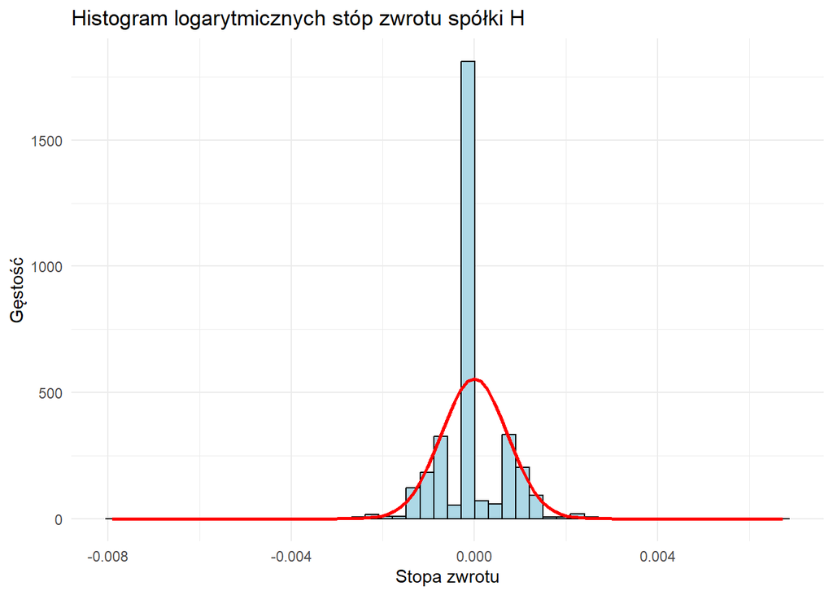

```r
p1 <- ggplot(data.frame(x = stopy_zwrotuH), aes(x = x)) +
  geom_histogram(aes(y = after_stat(density)), bins = 50, fill = "lightblue", color = "black") +
  stat_function(
    fun = dnorm,
    args = list(mean = mean(stopy_zwrotuH, na.rm = TRUE),
                sd = sd(stopy_zwrotuH, na.rm = TRUE)),
    color = "red",
    size = 1
  ) +
  labs(
    title = "Histogram logarytmicznych stóp zwrotu spółki H",
    x = "Stopa zwrotu",
    y = "Gęstość"
  ) +
  theme_minimal()
p1
```

Wnioski: Centralny, najwyższy słupek odpowiada małym, bliskim zeru zmianom cen, to sugeruje dominację „spokojnych” okresów. Na obu końcach histogramu widoczne są niewielkie, ale wyraźne słupki reprezentujące większe, bądź mniejsze stopy zwrotu, ale nie są to bardzo duże wzrosty, czy spadki. Czerwona krzywa, czyli gęstość rozkładu normalnego, nie pasuje do kształtu danych. Jest ona zbyt płaska w centrum i zbyt cienka w ogonach.

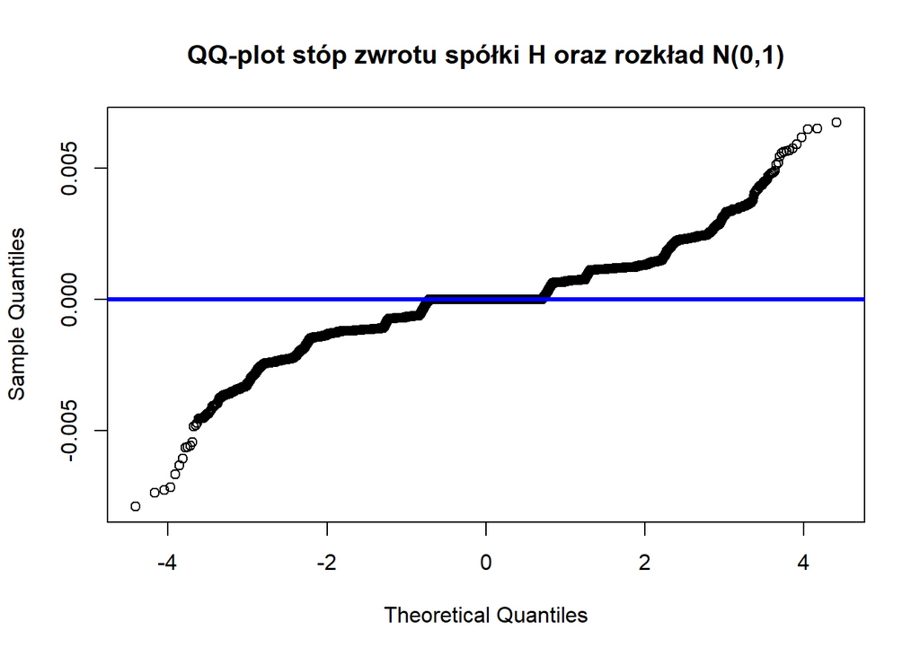

```r
p2 <- qqnorm(stopy_zwrotuH, main = "QQ-plot stóp zwrotu spółki H oraz rozkład N(0,1)")
qqline(stopy_zwrotuH, col = "blue", lwd = 3)
```

Wnioski: Na wykresie QQ-Plot widoczne są wyraźne odchylenia od linii teoretycznej, zwłaszcza w okolicy ogonów rozkładu. Punkty w prawym górnym oraz lewym dolnym rogu wyraźnie odchylają się od prostej, co potwierdza zauważoną wcześniej obecność obserwacji ekstremalnych, czyli grubych ogonów, a co za tym idzie niespełnienia założeń normalności. Rozkład rzeczywistych stóp zwrotu wychodzi poza granice rozkładu normalnego, zwłaszcza w kierunku dużych zmian cen.

#### Wykres autokorelacji stóp zwrotu ACF

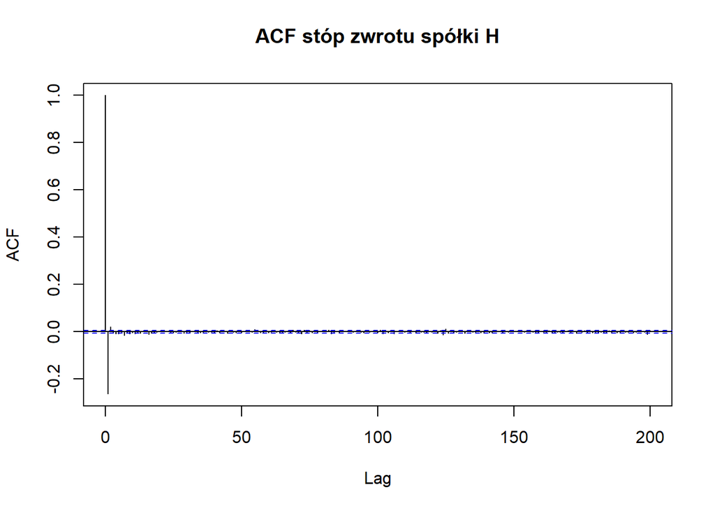

```r
acf(stopy_zwrotuH, main = "ACF stóp zwrotu spółki H", lag.max = 200)
```

```r
Box.test(stopy_zwrotuH, lag = 10, type = "Ljung-Box")
```

```
##
##  Box-Ljung test
##
## data:  stopy_zwrotuH
## X-squared = 6731.2, df = 10, p-value < 2.2e-16
```

Wnioski: Zauważalna jest silna, ujemna autokorelacja pierwszego rzędu (< -0,2), bo pierwszy lag wyraźnie wychodzi poza przedział ufności. To typowe zjawisko dla danych wysokiej częstotliwości, bo po każdej transakcji cena często odbija się w przeciwną stronę, co może być efektem mikrostruktury rynku.  
Dla wyższych opóźnień wartości autokorelacji szybko zanikają i pozostają w obrębie przedziału ufności, co sugeruje, że korelacja nie trwa dłużej niż jedną jednostkę czasu (sekundę). Stopy zwrotu nie są losowe, ale ich zależność jest krótkotrwała.

#### Wykres autokorelacji zmienności |r_t|

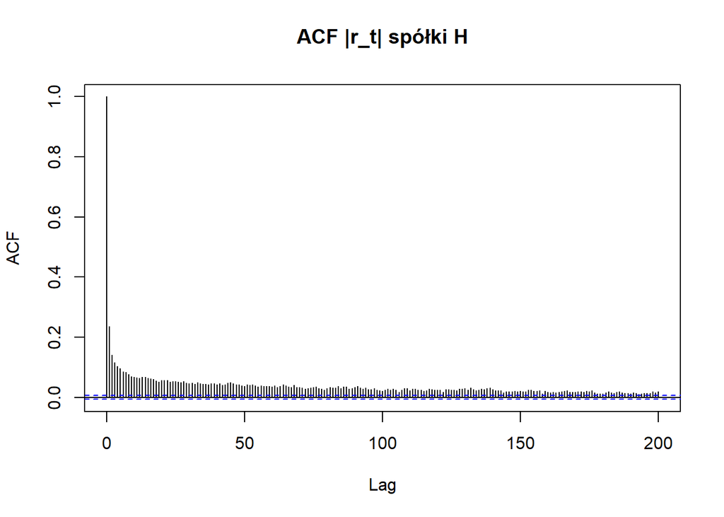

```r
acf(abs(stopy_zwrotuH), main = "ACF |r_t| spółki H", lag.max = 200)
```

```r
Box.test(abs(stopy_zwrotuH), lag = 10, type = "Ljung-Box")
```

```
##
##  Box-Ljung test
##
## data:  abs(stopy_zwrotuH)
## X-squared = 13393, df = 10, p-value < 2.2e-16
```

Wnioski: Wykres ACF zmienności, czyli wartości bezwzględnej stóp zwrotu, pokazuje silną dodatnią autokorelację rzędu 1 (ponad 0,2), która powoli wygasa wraz ze wzrostem lagu. To sygnał o tendencji do pojawiania się kolejnych okresów o wysokiej zmienności po sobie.  
Dodatnia autokorelacja w długim zakresie oznacza, że wysoka zmienność w okresie t, zwiększa szansę na wysoką zmienność w okresie t+1.

### 1.4.3. Obliczenia i wnioski dla spółki L

#### Skośność i kurtoza

```r
print(skosnoscL <- moments::skewness(stopy_zwrotuL))
```

```
## [1] -0.01422556
```

```r
print(kurtozaL <- moments::kurtosis(stopy_zwrotuL))
```

```
## [1] 8.497379
```

Wnioski: Kurtoza jest równa 8.497379 i wskazuje to na rozkład silnie leptokurtyczny, znacznie bardziej skupiony wokół średniej niż rozkład normalny, ale jednocześnie z występującymi grubymi ogonami. Oznacza to, że mimo dominacji małych zmian cen, czyli spokojnych sesji, ekstremalne stopy zwrotu pojawiają się znacznie częściej niż przewiduje to rozkład normalny. Jest to typowa cecha dla danych giełdowych, szczególnie przy wysokiej częstotliwości transakcji. Obliczona skośność wynosi -0.01422556, co oznacza, że rozkład logarytmicznych stóp zwrotu jest delikatnie skośny lewostronnie. Wartość ta jest bliska zero, co sugeruje symetryczny rozkład.

#### Test Jarque-Bera

```r
jb_test_L <- jarque.bera.test(stopy_zwrotuL)
cat("Test Jarque-Bera p-value:", jb_test_L$p.value, "\n")
```

```
## Test Jarque-Bera p-value: 0
```

Wnioski: Wartość p-value = 0 pozwala stwierdzić jednoznacznie o odrzuceniu hipotezy $H_0$ o zgodności rozkładu z rozkładem normalnym. Wynik potwierdza, że zarówno skośność jak i kurtoza istotnie różnią się od wartości spodziewanych w rozkładzie N(0,1), mimo pozornej symetrii.

#### Histogram i QQ-Plot

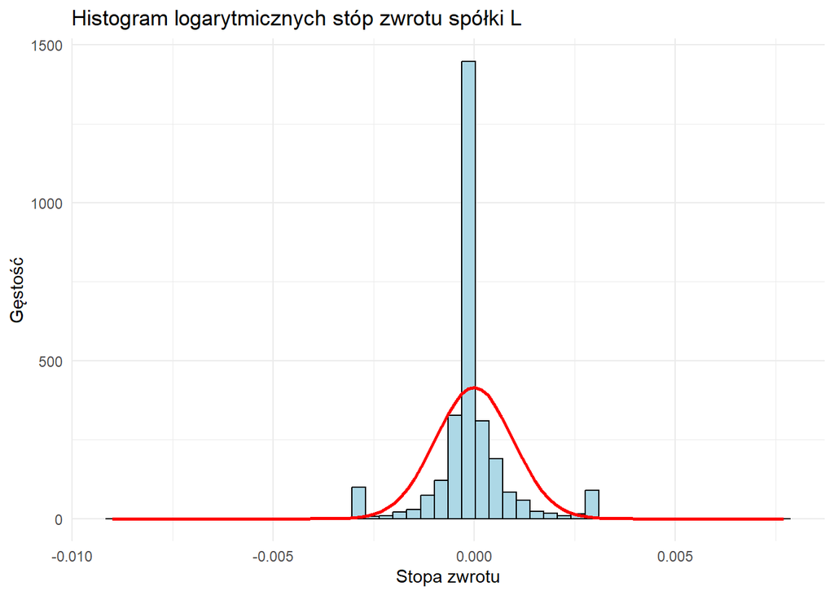

```r
p1 <- ggplot(data.frame(x = stopy_zwrotuL), aes(x = x)) +
  geom_histogram(aes(y = after_stat(density)), bins = 50, fill = "lightblue", color = "black") +
  stat_function(
    fun = dnorm,
    args = list(mean = mean(stopy_zwrotuL, na.rm = TRUE),
                sd = sd(stopy_zwrotuL, na.rm = TRUE)),
    color = "red",
    size = 1
  ) +
  labs(
    title = "Histogram logarytmicznych stóp zwrotu spółki L",
    x = "Stopa zwrotu",
    y = "Gęstość"
  ) +
  theme_minimal()
p1
```

Wnioski: Centralny, najwyższy słupek odpowiada małym, bliskim zeru zmianom cen, to sugeruje dominację „spokojnych” okresów. Na obu końcach histogramu widoczne są niewielkie, ale wyraźne słupki reprezentujące ekstremalne stopy zwrotu, zarówno bardzo duże wzrosty, jak i spadki. Czerwona krzywa, czyli gęstość rozkładu normalnego, nie pasuje do kształtu danych. Jest ona zbyt płaska w centrum i zbyt cienka w ogonach.

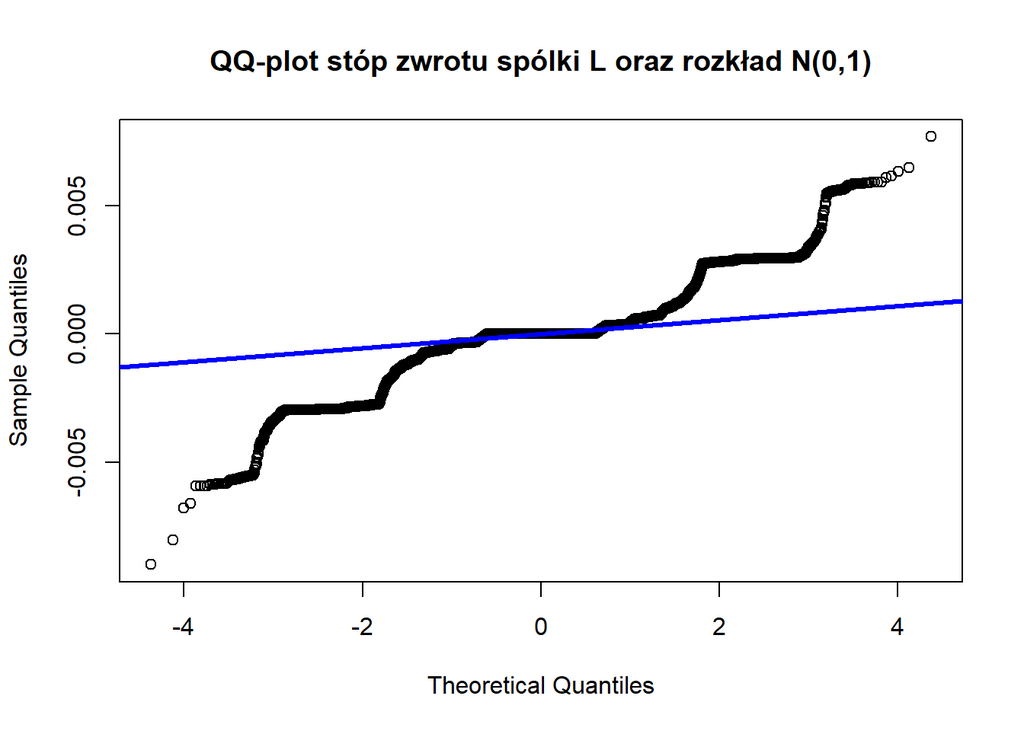

```r
p2 <- qqnorm(stopy_zwrotuL, main = "QQ-plot stóp zwrotu spólki L oraz rozkład N(0,1)")
qqline(stopy_zwrotuL, col = "blue", lwd = 3)
```

Wnioski: Na wykresie QQ-Plot widoczne są wyraźne odchylenia od linii teoretycznej, zwłaszcza w okolicy ogonów rozkładu. Punkty w prawym górnym oraz lewym dolnym rogu wyraźnie odchylają się od prostej, co potwierdza zauważoną wcześniej obecność obserwacji ekstremalnych, czyli grubych ogonów, a co za tym idzie niespełnienia założeń normalności. Rozkład rzeczywistych stóp zwrotu wychodzi poza granice rozkładu normalnego, zwłaszcza w kierunku dużych zmian cen.

#### Wykres autokorelacji stóp zwrotu ACF

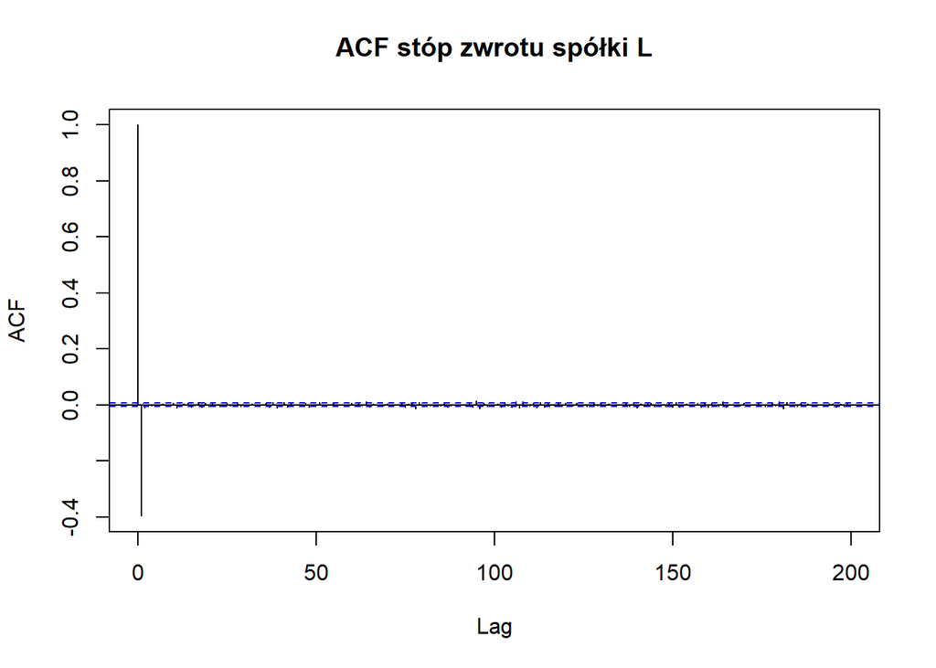

```r
acf(stopy_zwrotuL, main = "ACF stóp zwrotu spółki L", lag.max = 200)
```

```r
Box.test(stopy_zwrotuL, lag = 10, type = "Ljung-Box")
```

```
##
##  Box-Ljung test
##
## data:  stopy_zwrotuL
## X-squared = 12709, df = 10, p-value < 2.2e-16
```

Wnioski: Zauważalna jest silna, ujemna autokorelacja pierwszego rzędu (ok.-0,4), bo pierwszy lag wyraźnie wychodzi poza przedział ufności. To typowe zjawisko dla danych wysokiej częstotliwości, bo po każdej transakcji cena często odbija się w przeciwną stronę, co może być efektem mikrostruktury rynku.  
Dla wyższych opóźnień wartości autokorelacji szybko zanikają i pozostają w obrębie przedziału ufności, co sugeruje, że korelacja nie trwa dłużej niż jedną jednostkę czasu (sekundę). Stopy zwrotu nie są losowe, ale ich zależność jest krótkotrwała.

#### Wykres autokorelacji zmienności |r_t|

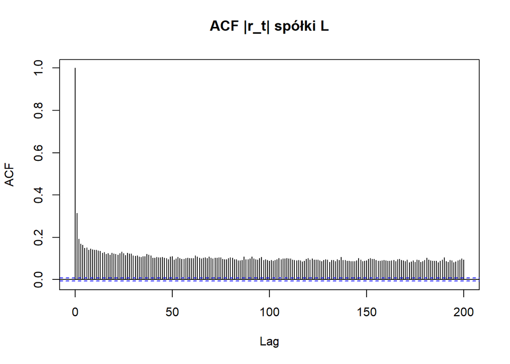

```r
acf(abs(stopy_zwrotuL), main = "ACF |r_t| spółki L", lag.max = 200)
```

```r
Box.test(abs(stopy_zwrotuL), lag = 10, type = "Ljung-Box")
```

```
##
##  Box-Ljung test
##
## data:  abs(stopy_zwrotuL)
## X-squared = 25636, df = 10, p-value < 2.2e-16
```

Wnioski: Wykres ACF zmienności, czyli wartości bezwzględnej stóp zwrotu, pokazuje silną dodatnią autokorelację rzędu 1 (około 0,3), która wraz ze wzrostem lagu zaczyna oscylować wokół wartości 0,1. To oznacza, że zmienność zachowuje się bardziej chaotycznie, ale z niewielką trwałą pamięcią. Nawet po wielu opóźnieniach nadal istnieje słaba, ale statystycznie istotna zależność między kolejnymi wartościami zmienności. To wskazuje na mniejszą możliwość przewidywania zmienności dla tej spółki, właśnie ze wsględu na powolne wygasanie autokorelacji. Modelowanie może wymagać innych podejść.

# 2. Analiza danych pięciominutowych

## 2.1. Agregacja do 5-minutowych interwałów

```r
#funkcja pomocnicza
przetworz_5min <- function(data_sekunda) {

  #agregacja do 5-minutowych interwalow
  data_5min <- data_sekunda %>%
    mutate(
      interval_5min = floor_date(znacznik, "5 minutes")
    ) %>%
    group_by(interval_5min) %>%
    summarise(
      close_price = last(cena),
      volume = sum(vol, na.rm = TRUE),
      trans_count = sum(ile_tickow, na.rm = TRUE),
      .groups = "drop"
    ) %>%
    mutate(data_sesji = as.Date(interval_5min))

  #dla kazdego dnia znajduje ostatnia cene przed 17:00
  data_final <- data_5min %>%
    group_by(data_sesji) %>%
    arrange(interval_5min) %>%
    mutate(
      #czy dany interwał jest poza godzinami ciaglymi
      is_overtime = interval_5min >= ymd_hms(paste(data_sesji, "17:00:00")),

      #ostatnia cena z sesji ciaglej (przed 17:00)
      last_cont_price = close_price[!is_overtime][length(close_price[!is_overtime])],

      #lag: dla dogrywki użyj last_cont_price, inaczej standardowy lag
      lag_price = ifelse(is_overtime, last_cont_price, lag(close_price))
    ) %>%
    ungroup() %>%
    mutate(
      log_ret = log(close_price / lag_price),
      log_vol = log(volume)
    ) %>%
    filter(!is.na(log_ret), is.finite(log_vol)) %>%
    mutate(pora_dnia = format(interval_5min, "%H:%M")) %>%
    select(-is_overtime, -last_cont_price, -lag_price)

  return(data_final)
}
```

```r
dataH_sekunda <- dataH %>%
  mutate(
    znacznik_sekunda = round_date(znacznik, "second"),
    wartosc = cena*vol
  ) %>%
  group_by(znacznik_sekunda) %>%
  summarise(
    cena = sum(cena*vol, na.rm=T) / sum(vol, na.rm=T),
    vol = sum(vol, na.rm=T),
    wartosc = sum(wartosc, na.rm=T),
    ile_tickow = n(),
    .groups = "drop"
  ) %>%
  rename(znacznik = znacznik_sekunda) %>%
  filter(!is.na(cena), cena>0)

dataL_sekunda <- dataL %>%
  mutate(
    znacznik_sekunda = round_date(znacznik, "second"),
    wartosc = cena*vol
  ) %>%
  group_by(znacznik_sekunda) %>%
  summarise(
    cena = sum(cena*vol, na.rm=T) / sum(vol, na.rm=T),
    vol = sum(vol, na.rm=T),
    wartosc = sum(wartosc, na.rm=T),
    ile_tickow = n(),
    .groups = "drop"
  ) %>%
  rename(znacznik = znacznik_sekunda) %>%
  filter(!is.na(cena), cena>0)

dataH_sekunda <- dataH_sekunda %>%
  mutate(
    znacznik = case_when(
      hour(znacznik) == 17 & minute(znacznik) <= 5 ~
        znacznik - minutes(minute(znacznik)) - seconds(second(znacznik)),
      TRUE ~ znacznik
    )
  )

dataL_sekunda <- dataL_sekunda %>%
  mutate(
    znacznik = case_when(
      hour(znacznik) == 17 & minute(znacznik) <= 5 ~
        znacznik - minutes(minute(znacznik)) - seconds(second(znacznik)),
      TRUE ~ znacznik
    )
  )

dataH_sekunda <- dataH_sekunda %>%
  mutate(data = as.Date(znacznik)) %>%
  group_by(data) %>%
  mutate(log_stopa_zwrotu = log(cena / lag(cena))) %>%
  ungroup()

stopy_zwrotuH <- dataH_sekunda %>%
  pull(log_stopa_zwrotu) %>%
  na.omit()

dataL_sekunda <- dataL_sekunda %>%
  mutate(data = as.Date(znacznik)) %>%
  group_by(data) %>%
  mutate(log_stopa_zwrotu = log(cena / lag(cena))) %>%
  ungroup()

stopy_zwrotuL <- dataL_sekunda %>%
  pull(log_stopa_zwrotu) %>%
  na.omit()

dataH_5min <- przetworz_5min(dataH_sekunda)
dataL_5min <- przetworz_5min(dataL_sekunda)
```

## 2.2. Obliczanie średnich przekrojowych (profile dzienne)

```r
intraday_means <- function(df){
  df %>%
    group_by(pora_dnia) %>%
    summarise(
      mean_ret = mean(log_ret, na.rm = T),
      mean_count = mean(trans_count, na.rm = T),
      mean_log_vol = mean(log(volume+1), na.rm = T),
      mean_abs_ret = mean(abs(log_ret), na.rm=T)
    ) %>%
    mutate(time_plot = as.POSIXct(paste("2020-01-01", pora_dnia)))
}

intradayH <- intraday_means(dataH_5min)
intradayL <- intraday_means(dataL_5min)
```

## 2.3. Kod tworzący wykresy

```r
plot_intraday <- function(df_seas, company_name) {

  breaks_vec <- unique(df_seas$pora_dnia)
  breaks_vec <- breaks_vec[seq(1, length(breaks_vec), by = 6)]


  p1 <- ggplot(df_seas, aes(x = pora_dnia, y = mean_ret, group = 1)) +
    geom_line(color = "darkgreen") +
    geom_hline(yintercept = 0, linetype="dashed", color="gray") +
    scale_x_discrete(breaks = breaks_vec) +
    labs(title = paste("1. Przekrojowe średnie stopy zwrotu -", company_name),
         x = "Godzina", y = "Średnia stopa zwrotu") +
    theme_minimal() +
    theme(axis.text.x = element_text(angle = 90, vjust = 0.5))

  p2 <- ggplot(df_seas, aes(x = pora_dnia, y = mean_count, group = 1)) +
    geom_line(color = "purple", size=1) +
    scale_x_discrete(breaks = breaks_vec) +
    labs(title = paste("2. Średnia liczba transakcji -", company_name),
         x = "Godzina", y = "Liczba transakcji") +
    theme_minimal() +
    theme(axis.text.x = element_text(angle = 90, vjust = 0.5))

  p3 <- ggplot(df_seas, aes(x = pora_dnia, y = mean_log_vol, group=1)) +
    geom_line(color = "steelblue", size=1) +
    scale_x_discrete(breaks = breaks_vec) +
    labs(title = paste("3. Średni log-wolumen -", company_name),
         x = "Godzina", y = "Log(Wolumen)") +
    theme_minimal() +
    theme(axis.text.x = element_text(angle = 90, vjust = 0.5))


  p4 <- ggplot(df_seas, aes(x = pora_dnia, y = mean_abs_ret, group = 1)) +
    geom_line(color = "red", size=1) +
    scale_x_discrete(breaks = breaks_vec) +
    labs(title = paste("4. Sezonowość zmienności (|r_t|) -", company_name),
         subtitle = "Wykres ciągły (bez przerwy przed dogrywką)",
         x = "Godzina", y = "Średnia |stopa zwrotu|") +
    theme_minimal() +
    theme(axis.text.x = element_text(angle = 90, vjust = 0.5))

  return(list(p1 = p1, p2 = p2, p3 = p3, p4 = p4))
}
```